# Credit Risk Analysis and Modeling

[Introduction to dataset]

1. Loading and Understanding the Dataset

2. Data Pre-processing For Ordinal Columns

3. EDA

4. Data Pre-processing For Discrete Categorical Columns

5. Predicting the Risk

6. Modeling selection

7. Model

# Introduction to dataset

The Statlog (German Credit Data) data set is a commonly used data set for modeling credit risk analysis. It contains data on 1,000 loan applicants from a German bank, and the objective is to predict whether an applicant is a good or bad credit risk based on various attributes such as their credit history, employment status, and personal information.

The dataset has 9 input attributes such as credit history, purpose of the loan, personal status and sex, property status and housing type, employment status, age, and others, and one target attribute which is binary indicating whether the credit risk is good or bad.

The Statlog (German Credit Data) data set has been widely used for building models for risk analysis, credit scoring, and decision-making systems in banking and finance. Many classification algorithms, such as logistic regression, decision trees, and neural networks have been applied to this dataset, and it has become a standard benchmark for evaluating the performance of different models in the context of credit risk analysis. More details [click here](https://archive.ics.uci.edu/ml/datasets/Statlog+%28German+Credit+Data%29)

```python
import numpy as np
import pandas as pd
import seaborn as sns
import matplotlib.pyplot as plt
from IPython.display import display, Markdown, Latex

from sklearn.preprocessing import LabelEncoder
from sklearn import model_selection
from sklearn.svm import SVC
from sklearn.tree import DecisionTreeClassifier
from sklearn.ensemble import RandomForestClassifier
from sklearn.naive_bayes import GaussianNB
from sklearn.linear_model import LogisticRegression

from sklearn.metrics import f1_score

# To ignore deprecation warnings in Python
import warnings
warnings.filterwarnings("ignore")
```

# 1. Loading and Understanding the Dataset

```python
df = pd.read_csv("./credit_data.csv", index_col = 0)
df.head()
```

|  | Age | Sex | Job | Housing | Saving accounts | Checking account | Credit amount | Duration | Purpose | Risk |
| --- | --- | --- | --- | --- | --- | --- | --- | --- | --- | --- |
| 0 | 67 | male | 2 | own | NaN | little | 1169 | 6 | radio/TV | good |
| 1 | 22 | female | 2 | own | little | moderate | 5951 | 48 | radio/TV | bad |
| 2 | 49 | male | 1 | own | little | NaN | 2096 | 12 | education | good |
| 3 | 45 | male | 2 | free | little | little | 7882 | 42 | furniture/equipment | good |
| 4 | 53 | male | 2 | free | little | little | 4870 | 24 | car | bad |

```python
df.info()
```

```
<class 'pandas.core.frame.DataFrame'>
Int64Index: 1000 entries, 0 to 999
Data columns (total 10 columns):
 #   Column            Non-Null Count  Dtype
---  ------            --------------  -----
 0   Age               1000 non-null   int64
 1   Sex               1000 non-null   object
 2   Job               1000 non-null   int64
 3   Housing           1000 non-null   object
 4   Saving accounts   817 non-null    object
 5   Checking account  606 non-null    object
 6   Credit amount     1000 non-null   int64
 7   Duration          1000 non-null   int64
 8   Purpose           1000 non-null   object
 9   Risk              1000 non-null   object
dtypes: int64(4), object(6)
memory usage: 85.9+ KB
```

```python
df.isnull().sum()
```

```
Age                   0
Sex                   0
Job                   0
Housing               0
Saving accounts     183
Checking account    394
Credit amount         0
Duration              0
Purpose               0
Risk                  0
dtype: int64
```

There are missing values in columns "Saving accounts" and "Checking accounts".

Explore the Values of Text Columns:

```python
cols = ['Sex', 'Housing', 'Saving accounts', 'Checking account', 'Purpose', 'Risk']
for col in cols:
    line = "**" + col + ":** "
    for v in df[col].unique():
        line = line + str(v) + ", "
    display(Markdown(line))
```

**Sex:** male, female,

**Housing:** own, free, rent,

**Saving accounts:** nan, little, quite rich, rich, moderate,

**Checking account:** little, moderate, nan, rich,

**Purpose:** radio/TV, education, furniture/equipment, car, business, domestic appliances, repairs, vacation/others,

**Risk:** good, bad,

From above exploration:

- Columns "Housing", "Saving accounts" and "Checking accounts" are **Ordinal** data.
- Columns "Sex", "Purpose" and "Risk" are **Categorical** data.

# 2. Data Pre-processing For Ordinal Columns

Known from Content in the dataset page, column "Job" is **Ordinal** data that:

- 0 - unskilled and non-resident,
- 1 - unskilled and resident,
- 2 - skilled,
- 3 - highly skilled

SO, apply the save logic to other **Ordinal** columns "Housing", "Saving accounts" and "Checking accounts".

For "Saving accounts" and "Checking accounts":

- 0 - missing value, as UNKNOWN
- 1 - little
- 2 - moderate
- 3 - quite rich
- 4 - rich

For "Housing":

- 0 - free
- 1 - rent
- 2 - own

```python
# label encode account quality and fill NaN with 0
def SC_LabelEncoder(text):
    if text == "little":
        return 1
    elif text == "moderate":
        return 2
    elif text == "quite rich":
        return 3
    elif text == "rich":
        return 4
    else:
        return 0

df["Saving accounts"] = df["Saving accounts"].apply(SC_LabelEncoder)
df["Checking account"] = df["Checking account"].apply(SC_LabelEncoder)
```

```python
# label encode account quality and fill NaN with 0
def H_LabelEncoder(text):
    if text == "free":
        return 0
    elif text == "rent":
        return 1
    elif text == "own":
        return 2

df["Housing"] = df["Housing"].apply(H_LabelEncoder)
```

# 3. EDA

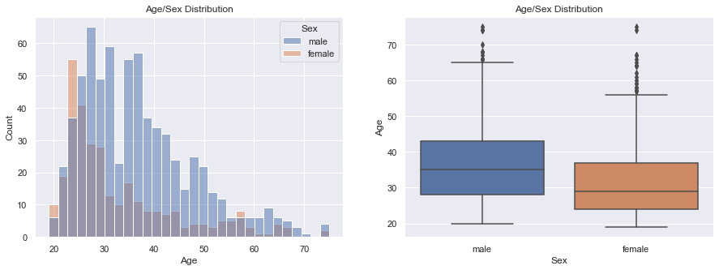

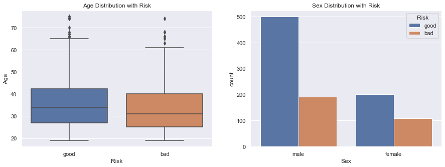

```python
fig, ax = plt.subplots(1,2,figsize=(15,5))
sns.histplot(df, x='Age', bins=30, hue="Sex", ax=ax[0]).set_title("Age/Sex Distribution");
sns.boxplot(data=df, x="Sex", y="Age", ax=ax[1]).set_title("Age/Sex Distribution");

fig, ax = plt.subplots(1,2,figsize=(15,5))
sns.boxplot(data=df, x='Risk', y='Age', ax=ax[0]).set_title("Age Distribution with Risk");
sns.countplot(data=df, x="Sex", hue="Risk", ax=ax[1]).set_title("Sex Distribution with Risk");
```

**Analysis:**

- Age does not affect the risk rating much.
- Males take more count of credit from Bank.
- Males have lower percentage of bad rating than woman.f

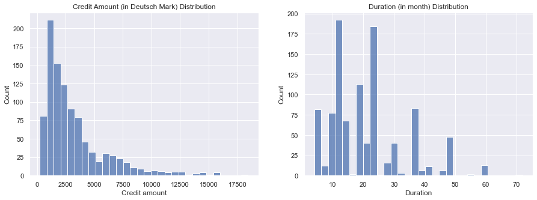

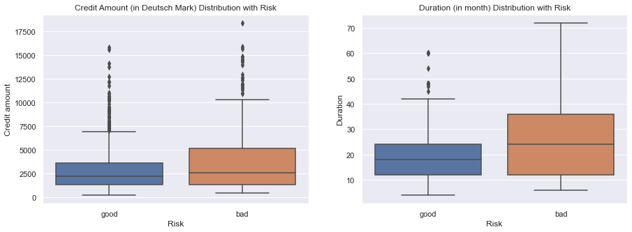

```python
fig, ax = plt.subplots(1,2,figsize=(15,5))
sns.histplot(df, x='Credit amount', bins=30, ax=ax[0]).set_title("Credit Amount (in Deutsch Mark) Distribution");
sns.histplot(df, x='Duration', bins=30, ax=ax[1]).set_title("Duration (in month) Distribution");

fig, ax = plt.subplots(1,2,figsize=(15,5))
sns.boxplot(data=df, x='Risk', y='Credit amount', ax=ax[0]).set_title("Credit Amount (in Deutsch Mark) Distribution with Risk");
sns.boxplot(data=df, x='Risk', y='Duration', ax=ax[1]).set_title("Duration (in month) Distribution with Risk");
```

**Analysis:** The higher credit amount and longer duration means higher risk to the bank.

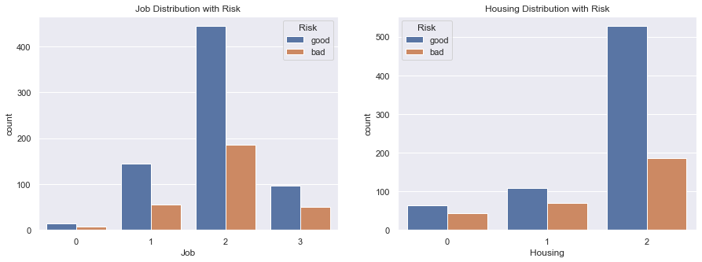

```python
fig, ax = plt.subplots(1,2, figsize=(15,5))
sns.countplot(data=df, x="Job", hue="Risk", ax=ax[0]).set_title("Job Distribution with Risk");
sns.countplot(data=df, x="Housing", hue="Risk", ax=ax[1]).set_title("Housing Distribution with Risk");
```

**Analysis:**

- Most of people in records have job skill level 2, but the job skill level does not affect the risk rating much.
- People who own a house means low risk and good rating to the bank.

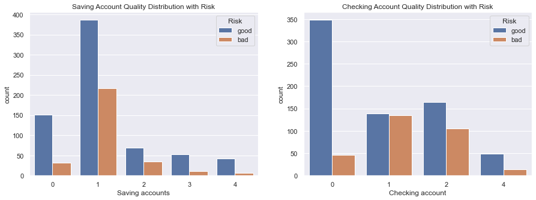

```python
fig, ax = plt.subplots(1,2, figsize=(15,5))
sns.countplot(data=df, x="Saving accounts", hue="Risk", ax=ax[0]).set_title("Saving Account Quality Distribution with Risk");
sns.countplot(data=df, x="Checking account", hue="Risk", ax=ax[1]).set_title("Checking Account Quality Distribution with Risk");
```

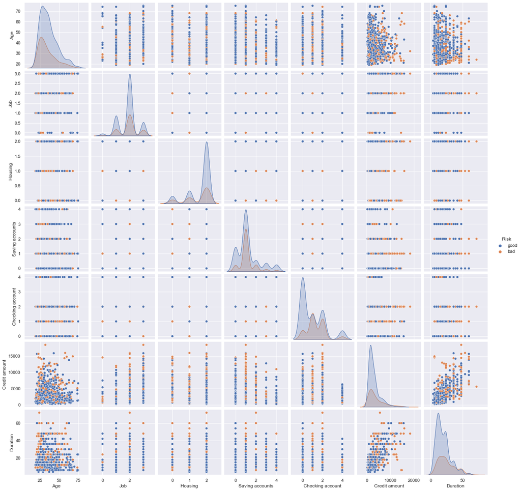

```python
sns.pairplot(df[['Age', 'Job', 'Housing', 'Saving accounts',
                 'Checking account', 'Credit amount', 'Duration', "Risk"]], hue="Risk");
```

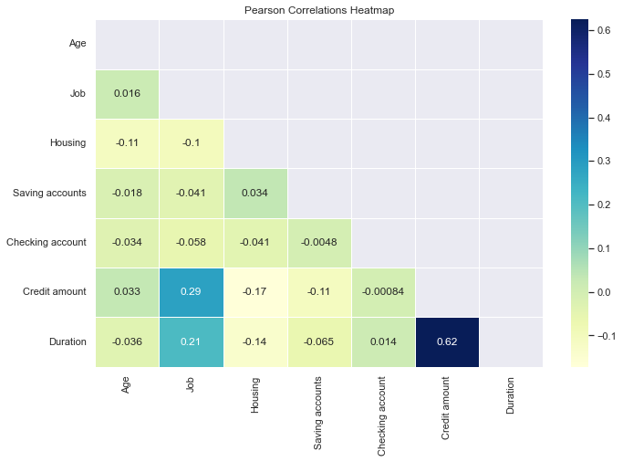

```python
corr = df[['Age', 'Job', 'Housing', 'Saving accounts', 'Checking account', 'Credit amount', 'Duration']].corr()
sns.set(rc={'figure.figsize':(11,7)})
sns.heatmap(corr,linewidths=.5, annot=True, cmap="YlGnBu",mask=np.triu(np.ones_like(corr, dtype=np.bool)))\
    .set_title("Pearson Correlations Heatmap");
```

**Analysis:** The Credit Amount is HIGHLY and POSITIVELY related to the Duration.

```python
df["Risk"].value_counts()
```

```
good    700
bad     300
Name: Risk, dtype: int64
```

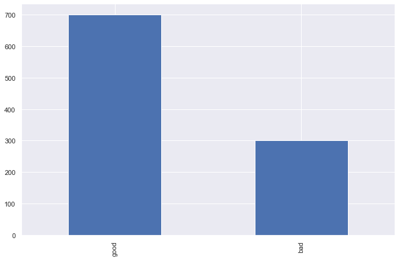

```python
df["Risk"].value_counts().plot(kind= 'bar');
```

# 4. Data Pre-processing For Discrete Categorical Columns

```python
# use LabelEncoder() to encode other categorical columns:
for col in ["Sex", "Purpose", "Risk"]:
    le = LabelEncoder()
    le.fit(df[col])
    df[col] = le.transform(df[col])
df.head()
```

|  | Age | Sex | Job | Housing | Saving accounts | Checking account | Credit amount | Duration | Purpose | Risk |
| --- | --- | --- | --- | --- | --- | --- | --- | --- | --- | --- |
| 0 | 67 | 1 | 2 | 2 | 0 | 1 | 1169 | 6 | 5 | 1 |
| 1 | 22 | 0 | 2 | 2 | 1 | 2 | 5951 | 48 | 5 | 0 |
| 2 | 49 | 1 | 1 | 2 | 1 | 0 | 2096 | 12 | 3 | 1 |
| 3 | 45 | 1 | 2 | 0 | 1 | 1 | 7882 | 42 | 4 | 1 |
| 4 | 53 | 1 | 2 | 0 | 1 | 1 | 4870 | 24 | 1 | 0 |

# 5. Predicting the Risk

**Based on given Risk column**

```python
X, y = df.drop("Risk", axis=1), df["Risk"]
X_train, X_test, y_train, y_test = model_selection.train_test_split(X, y, test_size=0.20, random_state=0)
```

# 6. Modeling selection

```python
# Model Selection with Cross Validate
Models = {
    "Logistic": LogisticRegression(),
    "SVC": SVC(),
    "DecisionTree": DecisionTreeClassifier(),
    "RandomForest": RandomForestClassifier(),
    "GaussianNaiveBayes": GaussianNB()
}
```

```python
cv_results = pd.DataFrame(columns=['model', 'train_score', 'test_score'])
for key in Models.keys():
    cv_res = model_selection.cross_validate(Models[key], X_train, y_train,
                                             return_train_score=True,
                                             scoring="f1",
                                             cv=5, n_jobs=-1)
    res = {
        'model': key,
        'train_score': cv_res["train_score"].mean(),
        'test_score': cv_res["test_score"].mean(),
        'fit_time': cv_res["fit_time"].mean(),
        'score_time': cv_res["score_time"].mean(),
        }
    cv_results = cv_results.append(res, ignore_index=True)
    print("CV for model:", key, "done.")
cv_results
```

```
CV for model: Logistic done.
CV for model: SVC done.
CV for model: DecisionTree done.
CV for model: RandomForest done.
CV for model: GaussianNaiveBayes done.
```

|  | model | train_score | test_score | fit_time | score_time |
| --- | --- | --- | --- | --- | --- |
| 0 | Logistic | 0.814524 | 0.810308 | 0.016267 | 0.002201 |
| 1 | SVC | 0.826045 | 0.826072 | 0.016400 | 0.008402 |
| 2 | DecisionTree | 1.0 | 0.751637 | 0.003666 | 0.002803 |
| 3 | RandomForest | 1.0 | 0.819257 | 0.189872 | 0.015627 |
| 4 | GaussianNaiveBayes | 0.812051 | 0.811265 | 0.000000 | 0.000000 |

**Evaluate Model on Testing Set**

- Random Forest Classifier gives a good result on both train_score and test_score. **Taking all this into consideration, Random Forest Classifier is chose to evaluate on testing set:**

# 7. Model

**Handling imbalance data**

```python
from imblearn.over_sampling import SMOTE

smote = SMOTE()

# fit predictor and target variable
X_smote, y_smote = smote.fit_resample(df.iloc[:,:-1], df["Risk"])
```

```python
X_train, X_test, y_train, y_test = model_selection.train_test_split(
    X_smote, y_smote , test_size=0.2, random_state=42)
```

```python
from sklearn.ensemble import RandomForestClassifier
rf = RandomForestClassifier(random_state=42)

rf.fit(X_train, y_train)
```

```
RandomForestClassifier(random_state=42)
```

```python
y_predict = rf.predict(X_test)
```

**Evaluate Model**

```python
from sklearn.metrics import classification_report
print(classification_report(y_test, y_predict))
```

```
              precision    recall  f1-score   support

           0       0.71      0.82      0.76       131
           1       0.82      0.70      0.76       149

    accuracy                           0.76       280
   macro avg       0.77      0.76      0.76       280
weighted avg       0.77      0.76      0.76       280
```

```python
from sklearn.metrics import confusion_matrix
print(confusion_matrix(y_test, y_predict))
```

```
[[108  23]
 [ 44 105]]
```

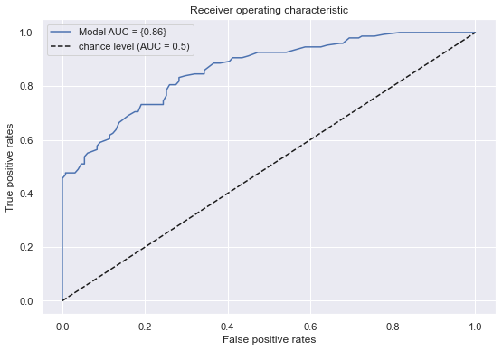

```python
from sklearn.metrics import roc_auc_score, roc_curve
import matplotlib.pyplot as plt

plt.figure(figsize=(9,6))
fpr, tpr, thresholds = roc_curve(y_test, rf.predict_proba(X_test)[:,1])
roc_au_s = roc_auc_score(y_test, rf.predict_proba(X_test)[:,1])
plt.plot(fpr,tpr, label="Model AUC = {%.2f}" %roc_au_s)
plt.plot([0, 1], [0, 1], "k--", label="chance level (AUC = 0.5)")
plt.title("Receiver operating characteristic")
plt.xlabel("False positive rates")
plt.ylabel("True positive rates")
plt.legend()
plt.show()
```

**Feature Importance Discussion**

```python
feature_importance = pd.DataFrame()
feature_importance["feature"] = X_train.columns
feature_importance["importance"] = rf.feature_importances_
feature_importance = feature_importance.sort_values("importance", ascending=False)
feature_importance
```

|  | feature | importance |
| --- | --- | --- |
| 6 | Credit amount | 0.222979 |
| 0 | Age | 0.159039 |
| 7 | Duration | 0.157523 |
| 5 | Checking account | 0.115960 |
| 8 | Purpose | 0.099962 |
| 4 | Saving accounts | 0.078321 |
| 3 | Housing | 0.070511 |
| 2 | Job | 0.058705 |
| 1 | Sex | 0.036998 |

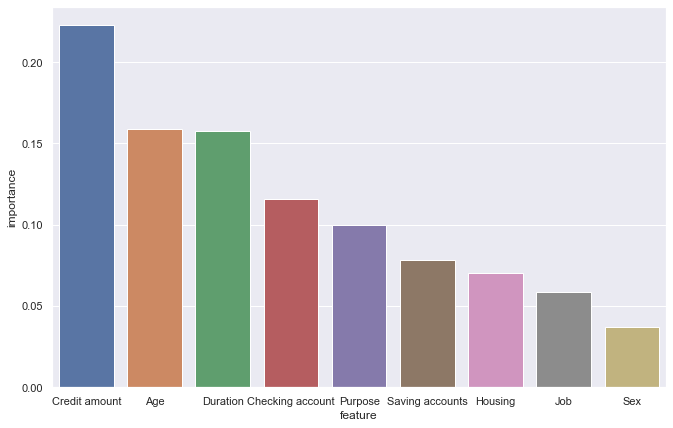

```python
sns.barplot(data=feature_importance, x = "feature", y="importance");
```